# Fueling Wellness - An Investigation on Lifestyle, Nutrition, and Its Reflection on our Health

Project Report for STAT 303-1 Fall 2025

Author

Jenna Religioso

Published

December 9, 2025

Abstract

*In this report, I will analyze relationships between nutrition, fitness, and overall health to investigate how lifestyle changes, such as making modifications in diet or exercise routine, can affect an individual’s overall health. This investigation also explores the relationship between the composition of nutrients in our diets and how it may affect our workout performance. The findings of this analysis can provide our stakeholders, who are typically people interested in changing their lifestyle habits to reach their personal fitness and health goals, an idea of which diets and exercise routine work best for them based on their body’s individualized needs. Naturally, there is a large variation in how people’s body’s function. Certain diets and exercise routines are not suitable for everyone due to factors such as height, weight, activity level, muscle mass, and so on. Therefore, in this report, I aim to analyze how varying lifestyle habits relate to different nutrition and fitness goals to help others understand that personal habits should be incorporated in a sustainable way based on personal goals rather than someone else’s*.

## 1) Inspiration

Lifestyle habits like nutrition and fitness is a very important part of my life. It is important to me that I pursue exercises and diets that are sustainable, while also tailoring to the needs of my individualized goals and bodily needs. Since I started putting effort into changing my habits, I have noticed a lot of positive changes in my health and mindest. After finding a routine that works for me, I realize that it may not work for someone else.

In a world dominated by media and numerous information outlets, it is inevitable to encounter inaccurate information with little to no supporting scientific evidence or source citations. According to National Geographic, “evaluating influencer posts on Instagram found that 86 percent of nutrition content didn’t cite any scientific sources” and “97 percent of popular weight loss, muscle-building, and detox supplement videos on TikTok offered no scientific evidence to support their claims” [1] For a topic as important as health and lifestyle, it is vital to receive accurate information in terms of diet and exercise.

Additionally, influencers on social media can promote unsustainable, or even disordered mindsets when thinking about exercise and nutrition. At the beginning of my journey of changing my lifestyle habits, I was especially gullible amidst social media influencers, especially if they have a certain physique/habit I wanted to progress towards. Consequently, it was easy to believe social media influencers without questioning their credibility. For example, according to New York Times, “what I eat in a day videos” may promote diets that don’t fit everyone’s bodily needs in terms of height, weight, and body composition [2]. As a result, people may incorporate habits into their lives that do more harm than good to their body’s individual needs. It is crucial that people are not misinformed about a topic as important as fitness and nutrition. People must understand that everyone’s bodies have different needs to be healthy. Additionally, people’s fitness goals may also be different (e.g. want to build more muscle vs. improve cardiovascular endurance), which is also an important factor that may lead to nutrition and fitness variation among people. Therefore, it is important to be more skeptical of unsupported claims by social media influencers and be more willing to go out and look for reliable, scientifically supported information when making lifestyle decisions.

## 2) Problem Statements

1. How do people with different diet types and macronutrient intake differ in workout performance metrics?
2. How do health metrics differ across groups with different fitness experience levels and workout frequencies?
3. Does following a specific diet correspond to a preference for certain types of workouts, and do these preferences affect daily caloric burn?

## 3) Data

**Data Identification**: ‘Life Style Data’ from Kaggle: https://www.kaggle.com/datasets/jockeroika/life-style-data. The dataset contains information about various lifestyle factors (e.g., workout type, workout duration), health metrics (e.g., age, gender, weight, heart rate), and nutrition (e.g., protein/fat/carb intake).

#### Data Description

- The dataset contains 20,000 observations and 54 variables, where each observation represents a person.
- Of the 54 variables, there are 39 numeric variables:
  - **Health metric variables**
    - Age
    - Weight (kg)
    - Height (m)
    - Fat_Percentage
    - BMI
    - Max BPM: Maximum heart rate recorded during a workout session.
    - Avg_BPM: Average heart rate maintained during the session.
    - Resting_BPM: Resting heart rate before starting the workout.
    - lean_mass_kg: Total body weight minus fat mass.
  - **Workout assessment variables**
    - Session_Duration (hours)
    - Workout_Frequency (days/week): Average number of days an individual workouts in a week, given as a float.
    - Calories_Burned: Total calories burned in a day
    - Experience_Level: Fitness experience level (as a float) on a scale of 1–3.05, where 3.05 is the most experienced.
    - Sets: Number of sets completed in the exercise.
    - Reps: Number of repetitions per set.
    - Burns Calories (per 30 min): Estimated calories burned in 30 minutes of the exercise.
  - **Nutrition-related variables**
    - Water_Intake (liters)
    - Daily meals frequency
    - serving_size_g
    - prep_time_min
    - cook_time_min
    - Carbs: Daily intake of carbs in grams.
    - Proteins: Daily intake of protein in grams.
    - Fats: Daily intake of fats in grams.
    - Calories: Total daily calorie intake from food.
    - sugar_g: Sugar content in milligrams per meal.
    - sodium_g: Sodium content in milligrams per meal.
    - cholesterol_mg: Cholesterol content in milligrams per meal.
    - protein_per_kg: Grams of protein consumed per kg of body weight.
  - The remaining continuous variables relate to workout ratings or additional calculations (e.g., macronutrient percentages), though some are not clearly defined by the dataset creator.
- Of the 54 variables, there are 15 categorical variables:
  - Gender: Biological sex (male/female).
  - Workout_Type: Type of workout performed (e.g., Strength, HIIT, Cardio).
  - meal_name: Name of the meal (breakfast, lunch, dinner).
  - meal_type: Type of meal (e.g., snack, main, beverage).
  - diet_type: Type of diet followed (e.g., KETO, vegan).
  - cooking_method: Cooking method used (e.g., boiled, fried).
  - Name of Exercise: Exercise performed.
  - Benefit: Physical benefit of the exercise.
  - Target Muscle Group: Muscle group targeted by the exercise.
  - Equipment Needed: Equipment required to perform the exercise.
  - Difficulty Level: Difficulty level (Beginner, Intermediate, Advanced).
  - Additional categorical variables describe specific body parts or muscle groups involved in each exercise.

In this report, the variables that will be used are: Proteins, Carbs, Fats, Burns Calories (per 30 min), Session_Duration (hours), diet_type, Gender, Fat_Percentage, Workout_Frequency (days/week), BMI, Resting_BPM, Experience_Level, Calories_Burned, and Workout_Type, adding up to a total of 14 variables.

**DISCLAIMER**: After performing data analysis with this datasat, I discovered that the dataset had very little variation and was artifically uniform, where there were no distinguishable relationships between isolated variables. The data is likely synthetic and artificially generated rather than derived from a real world source. I asked Professor Besler privately on Campuswire how I should approach working with this data, in which I was told to continue my report as if the dataset is not synthetic and draw conclusions based on what I could find. The results may be inconsistent with real world ideas, but I still worked with the results that I was able to receive.

## 4) Stakeholders

The findings of this project can be useful for people who are interested in making lifestyle changes to incorporate more exercise into their life and improve their nutrition based on their individualized goals. It can help people get a general sense of how macronutrients affect their exercise performance, so that they can gauge whether they should start incorporating more/less of a certain thing in their diet according to their personal goals. It can also generate a sense of motivation for individuals to see correlations between exercise and health metrics with their own eyes, encouraging them to cultivate a sustainable, long-term balance between diet and exercise. These reults may also provide ordinary people an opportunity to feel less overwhelmed by conflicting information they see on social media, as the information influencers provide can not be generalized to every individual because of differences in bodily needs and personal goals. Most importantly, these findings can demystify other fitness skepticisms by explicitly analyzing relationships between nutrition and fitness, which is different than believing another person’s words, especially if they are a social media influencer instead of someone like a nutritionist.

This information can also be beneficial for fitness trainers as well. Each client may have their own set of goals and dietary restrictions/preferences. The information from this project can help them formulate personalized training and nutrition plans, and make general recommendations based on a client’s individualized body needs and personal fitness goals.

## 5) Data Cleaning

### a) Cleaning - Question 1

To explore this question, I plan on focusing on the variables diet_type, Proteins, Fats, Carbs, Burns Calories (per 30 min), Session_Duration (hours), and Gender to examine the relationship between an individual’s diet/macronutrient consumption and their workout performance for both males and females.

#### Missing Values

There are no missing values in any of the variables that I plan on analyzing further. Therefore, I will not need to impute any missing values.

#### Outliers

The Session_Duration (hours) variable has no outliers. Otherwise, there are a few variables that have outliers.

- Proteins has 403 outliers
- Carbs has 405 outliers
- Fats has 399 outliers
- Burns Calories (per 30 min) has 893 outliers

I choose to keep all of the outliers in the data because naturally, macronutrient intake vary a lot across different types of diets. Different diet types may intentionally produce “outlier” macronutrient patterns (e.g. KETO diets have extremely high fat intake and extremely low carb intake). Additionally, outliers may be important in explaining differences in performance (e.g. extremely high protein intake can indicate body-building habits). Similarly, the Calories_Burned outliers is also valuable to keep due to its natural high variability (e.g. olympic athlete vs. person doing relaxing yoga). By choosing to keep outliers, it ensures that I will keep observations amidst a wide variation, which provides opportunity for more realistic analysis applicable to the real world where everyone’s lifestyle is different.

#### Categorical Variables

- The diet_type categorical variable has 6 categories, each category representing a different type of diet. Each diet type under this variable does not contain its own categories. Each diet type has at least 3000 observations, and is useful to utilize for further analysis when examining each diet type’s workout performances.
- The Gender categorical variable has 2 categories, Male and Female. Each gender under this variable does not contain its own categories. Each gender has about 10,000 observations, and is useful when comparing possible differences in diet type and workout performances for both categories.

#### Incorrect Values

For the remaining variables, there are no incorrect values where macronutrient intake, workout duration, or calories burned during exercise are less than or equal to 0. I also looked at the minimum and maximum values for each variable, and all the values of macronutrient intake and exercise metrics make sense and are possible to achieve in a real life context.

### b) Cleaning - Question 2

To delve further into this question, I plan on focusing on the variables Fat_Percentage, Workout_Frequency (days/week), Experience_Level, BMI, Resting_BPM, and Gender, to examine the relationship between an individual’s workout experience and frequency on overall health metrics across males in females in case that possible differences are not masked that would not be visible if I combined male and female information.

#### Missing Values

There are no missing values in any of the variables that I plan on analyzing further. Therefore, I will not need to impute any missing values.

#### Outliers

The Workout_Frequency (days/week), Experience_Level, and Resting_BPM variables have no outliers. Otherwise, the other variables do have outliers:

- The Fat_Percentage variable has 1 outlier
- The BMI variable has 530 outliers

Under “Incorrect Values,” I will mention that there are unrealistic BMI values, that may contain some outliers, but I intend to focus more on impossible BMI values instead of solely focusing on outliers. In other words, if there are realistic BMI values that happen to be outliers, these observations will be kept. My analysis focuses on lifestyle changes, individuals with low or high BMIs should not be excluded for analysis to be as realistic as possible by including a variety of individuals.

#### Categorical Variables

- The Gender categorical variable has 2 categories, Male and Female. Each gender under this variable does not contain its own categories. Each gender has about 10,000 observations, and is useful when comparing possible differences in diet type and workout performances for both categories.

#### Incorrect Values

There are BMI values that are unrealistically low (e.g. BMI of 12). According to the World Health Organization, “A BMI < 16.0 is known to be associated with a markedly increased risk for ill health, poor physical performance, lethargy and even death; this cut-off point is therefore a valid extreme limit” [3]. **I decided to filter out observations below a BMI of 16** because these individuals’ health can contribute to “poor physical performance.” Since I am analyzing workout metrics, these observations may distort things such as mean values or variance in my analysis. Therefore, it is not worth it to keep these observations, and I have chosen to filter them out. BMIs this low also categorize a dangerous, or even fatal, state of health which may distort my analysis that contain observations of healthier individuals when comparing physical performance metrics. In other words, I intend on filtering out impossible values, or values representing a fatal state on my analysis. I will still keep observations of individuals that are underweight (i.e BMI of 16-18.5) as my analysis focuses on lifestyle changes, so including variety in the groups of people I analyze will be meaningful realistically.

Similarly, a BMI > 30 is classified as “Obese”, and is “a disease that is largely preventable through lifestyle changes” [3]. Therefore, I have decided to keep observations of higher BMI for the same reason stated above: this can be changed through lifestyle changes (e.g. fitness, nutrition), which is what this analysis is all about. After filtering out these values, there are 18,547 observations remaining that will be used for further analysis.

Otherwise, for the remaining continuous variables, there are no incorrect values related to health metrics.

### c) Cleaning - Question 3

To explore this question, I plan on utilizing the diet_type, Workout_type, and Calories_Burned variables to examine the relationship between workout preferences across diet types with calories burned.

#### Missing Values

There are no missing values in any of the variables that I plan on analyzing further. Therefore, I will not need to impute any missing values.

#### Outliers

The only continuous variable that I will be analyzing is Calories_Burned. The Calories_Burned variable has 507 outliers.

Under “Incorrect Values,” I will mention that there are unrealistic Calories_Burned values, which may or may not contain some of these outliers. I intend on focusing more on caloric burn values that are impossible in a real world setting instead of solely focusing on outliers. In other words, if there are realistic caloric burn values that happen to be outliers, these observations will still be kept. Realistically, there is a natural variation in how many calories an individual burns a day (during and outside of physical exercise) as a result of varying lifestyles. Therefore, keeping outliers that are extremely high or low (but still attainable in a real world setting) makes analysis as realistic and generalizable as possible.

#### Categorical Variables

- The diet_type categorical variable has 6 categories, each category representing a different type of diet. Each diet type under this variable does not contain its own categories. Each diet type has at least 3000 observations, and is useful to utilize for further analysis when examining each diet type’s relationship with workout type and caloric burn.
- The Workout_Type categorical variable has 4 categories, each category representing a different type of workout (e.g HIIT, yoga). Each workout type under this variable does not contain its own categories. Each workout type has approximately 5,000 observations, and is useful to utilize for further analysis when examining each workout type’s relationship with diet type and daily caloric burn.

#### Incorrect Values

There are Calories_Burned values that are unrealistically low (e.g. daily caloric burn of 323 calories). This extremely low value would be more justified if the dataset contained very young children (e.g. infants or toddlers), but minimum age in the dataset is 18 years old. Caloric burn as low as 323 as an adult is physically impossible in the real world. Therefore, I plan on removing observations that are unrealistic for people 18 and older. MacroFactor is a nutrition tracking app and smart coach that adjusts calorie and macronutrient targets based on individualized metabolism and fitness progress, utilizes a verified food database, which are more accurate than user-generated food databases. MacroFactor explains in an article title ‘*The (Surprisingly Wide) Range of BMRs in Adults*’ that “Starting with the extremes, you can find published instances of BMRs below 800 Calories per day (in the case of patients with anorexia), or exceeding 3700 Calories per day (in the case of extremely muscular athletes)” [4]. The article also delves into two studies: The Mifflin study, where “lowest female BMR was 927 Calories, and the lowest male BMR was 1030 Calories”, and the Pavlidou study, where “the lowest female BMR was 908 Calories, and the lowest male BMR was 1039 Calories” [4]. BMR refers to “basal metabolic rate,” and it relates to the total amount of calories (energy) required for your body to perform basic functions, such as breathing, digestion, etc. including at rest, which varies depending on factors like age, physical activity level, sex, etc. In this case, the Calories_Burned variable refers to BMR.

Using this information from MacroFactor’s article, I have decided to discard values in Calories_Burned under 1,000. Though there are recorded instances of individuals falling below this threshold, “it’s very rare for BMRs to fall outside the range of 1,200-2,200 Calories per day” [3]. I will still be keeping realistically extremely low and high observations (e.g. keeping 1000-1200 calorie observations and those above 2,200. The max in my data is 2890, which is still physically possible for athletes). However, a caloric intake below 1000 calories is physiologically improbable for adults, as even a small, sedentary female needs ~1200 calories a day to perform basic body functions. Additionally, caloric intake below 1000 calories is not characteristic of typical named diets (e.g. KETO, Vegan, etc.) which is what analysis focuses on for this question. My analysis does not focus on things like clinical cases of food restriction, and these observations will likely not meaningfully represent a diet type under the diet_type variable.

After filtering out these values, there are 13,420 observations remaining that will be used for further analysis.

## 6) Data Analysis

### a) Analysis 1

#### Average Macronutrient Intake and its Relationship on Average Workout Duration in Hours

To analyze the relationship of macronutrient intake (proteins, carbs, fats) on workout session duration (hours), I binned the macronutrient variables, where each bin corresponds to a low, moderate, and high intake of that specific macronutrient. I chose to do this as it can create more understandable categories and can be easily understood when comparing low, moderate, and high intake diets with different variables. To determine the thresholds of what determines things like a “high protein” or a “moderate fat” intake, I focused on categorizing observations based on the percentage of macronutrient intake from the total caloric intake (e.g low protein diets correspond to diets with <10% of total calories derived from protein mean the same thing for someone consuming 1,500 calories versus 3,000 calories a day). I chose to do this method because realistically, everyone’s bodily needs, caloric intake, and macronutrient intake are different. Using percentages instead of hardcoding values as the thresholds can evade subjectivity in what a low, moderate, or high intake is defined as.

For each macronutrient, I created the thresholds based off of Acceptable Macronutrient Distribution Ranges (AMDRs) mentioned in Medicine Libre Texts. This is a calculated range of how much energy from carbohydrate, fat, and protein is recommended for a healthy diet. The AMDRs are as follows: Protein 10-35%, Carbohydrate 45-65%, and Fat 20-35% [5].

|  | Macronutrient | Low–Moderate Threshold | Moderate–High Threshold |
| --- | --- | --- | --- |
| 0 | Protein | 10 | 35 |
| 1 | Carbs | 45 | 65 |
| 2 | Fats | 20 | 35 |

For each macronutrient, the AMDR range categorizes the “moderate” intake category for each macronutrient. Observations where an individual who consume macronutrients below the AMDR threshold have a “low-intake”, while individuals who consume macronutrients above the AMDR threshold have a “high-intake”. For example, someone who consumes 10% of their total caloric intake derived from protein have a “low-intake” of protein. Similarly, an individual who eats above 35% of their total caloric intake derived from fat have a “high-intake” of fat, and so on. This method of focusing on percentages rather than setting rigid thresholds ensures that everyone’s bodily needs are accounted for when categorizing low, moderate, or high intake of a specific macronutrient, instead of directly inputting an individual’s macronutrient intake in grams. For example, a “high protein” diet does not mean the same for everyone. Eating 80g of protein may be considered “high-protein” for one person, but “moderate-protein” for another because it may take up different percentages of their total caloric intake for the day. This method ensures is more realistic and applicable to the real world based off of a great variance of lifestyle and bodily needs.

After finding the thresholds, I created the bins based off of distribution of each macronutrient, labeling them as “low”, “moderate”, and “high” based off of the AMDRs provided above.

|  | Macronutrient | Low Intake Count | Moderate Intake Count | High Intake Count |
| --- | --- | --- | --- | --- |
| 0 | Protein | 350 | 18755 | 895 |
| 1 | Carbs | 7695 | 7789 | 4516 |
| 2 | Fats | 2434 | 11026 | 6540 |

Each macronutrient bin has a different number of observations with them, with a majority of observations under the “moderate intake” category for both protein and fats. The carb bin has significantly more observations in the “low intake” category compared to other macronutrients and observations are more evenly distributed across the bins than protein and fats.

Using these bins, I then moved onto visualizing the relationship between the percentages of macronutrient intake out of total calories with the average workout duration in hours. I chose to isolate and graph each macronutrient separately to allow for easier comparison across each macronutrient category and to easily distinguish if one macronutrient has a greater correlation on workout duration versus another. I also chose to create separate boxes by gender to account for possible bodily differences and differences in needs of males and females, which may be masked if averaged out into one singular plot.

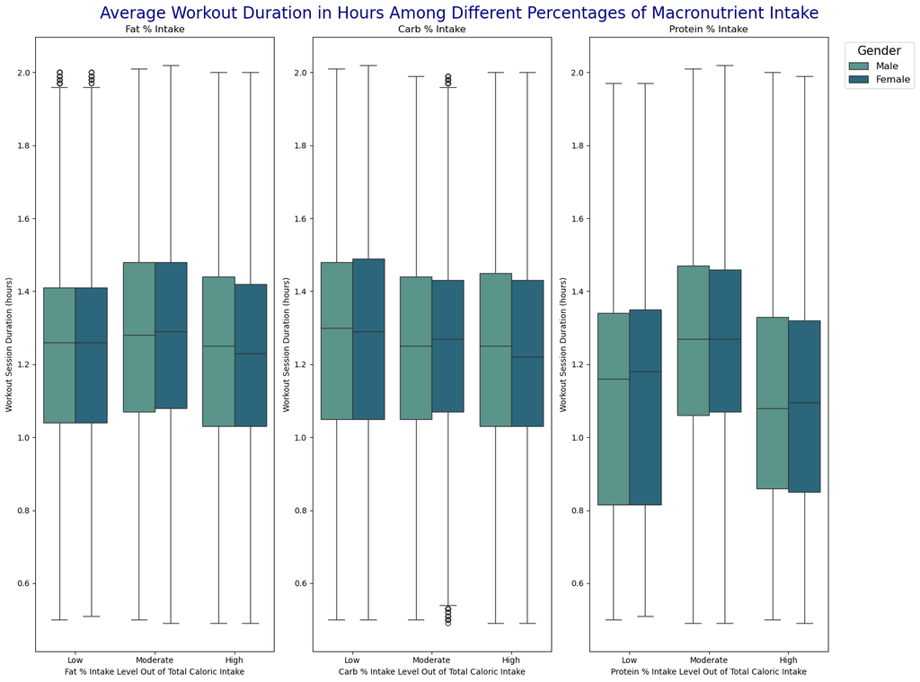

|  | Protein % Intake | Gender | count | mean | median | q1 | q3 | IQR | outliers |
| --- | --- | --- | --- | --- | --- | --- | --- | --- | --- |
| 0 | Low | Female | 175 | 1.109543 | 1.180 | 0.815 | 1.35 | 0.535 | 0 |
| 1 | Low | Male | 175 | 1.113714 | 1.160 | 0.815 | 1.34 | 0.525 | 0 |
| 2 | Moderate | Female | 9391 | 1.270229 | 1.270 | 1.070 | 1.46 | 0.390 | 0 |
| 3 | Moderate | Male | 9364 | 1.269620 | 1.270 | 1.060 | 1.47 | 0.410 | 0 |
| 4 | High | Female | 462 | 1.097056 | 1.095 | 0.850 | 1.32 | 0.470 | 0 |
| 5 | High | Male | 433 | 1.098337 | 1.080 | 0.860 | 1.33 | 0.470 | 0 |

|  | Carb % Intake | Gender | count | mean | median | q1 | q3 | IQR | outliers |
| --- | --- | --- | --- | --- | --- | --- | --- | --- | --- |
| 0 | Low | Female | 3857 | 1.285725 | 1.29 | 1.05 | 1.49 | 0.44 | 0 |
| 1 | Low | Male | 3838 | 1.286352 | 1.30 | 1.05 | 1.48 | 0.43 | 0 |
| 2 | Moderate | Female | 3875 | 1.258080 | 1.27 | 1.07 | 1.43 | 0.36 | 75 |
| 3 | Moderate | Male | 3914 | 1.244223 | 1.25 | 1.05 | 1.44 | 0.39 | 0 |
| 4 | High | Female | 2296 | 1.217609 | 1.22 | 1.03 | 1.43 | 0.40 | 0 |
| 5 | High | Male | 2220 | 1.239770 | 1.25 | 1.03 | 1.45 | 0.42 | 0 |

|  | Fat % Intake | Gender | count | mean | median | q1 | q3 | IQR | outliers |
| --- | --- | --- | --- | --- | --- | --- | --- | --- | --- |
| 0 | Low | Female | 1223 | 1.237244 | 1.26 | 1.04 | 1.41 | 0.37 | 20 |
| 1 | Low | Male | 1211 | 1.243518 | 1.26 | 1.04 | 1.41 | 0.37 | 26 |
| 2 | Moderate | Female | 5486 | 1.285684 | 1.29 | 1.08 | 1.48 | 0.40 | 0 |
| 3 | Moderate | Male | 5540 | 1.276812 | 1.28 | 1.07 | 1.48 | 0.41 | 0 |
| 4 | High | Female | 3319 | 1.224260 | 1.23 | 1.03 | 1.42 | 0.39 | 0 |
| 5 | High | Male | 3221 | 1.235567 | 1.25 | 1.03 | 1.44 | 0.41 | 0 |

Looking at the boxplots, there appears to be no concrete pattern that can be drawn relating the percentage of macronutrient intake out of total intake and its correlation on workout duration in hours. In the protein plot, the “low” and “high” boxplots appear to have more variation than the carb and fat plots, which is likely due to the very low number of observations in these categories. The “moderate” protein category contains 18,755 observations, while the “low” protein category contains only 350 observations and the “high” protein category contains 895 observations. This results in singular observations having greater effects on the trend when compared to the low and moderate categories of carbs and fats. As a result, it appears that lower protein and high protein intakes correlate to shorter workout durations. Otherwise, for males, the mean workout duration is approximately 1.23 - 1.28 hours, while the mean workout duration for females is is also 1.23 - 1.28 hours, which equates to a difference of 3 minutes for both males and females. The striking similarities in workout duration across all levels of macronutrient intake is surprising, implying that diets of varying percentages of macronutrient intake will be able to exercise for similar amounts of time.

Further supporting evidence for this observation is the similarities in median and interquartile range. Again noting that the “low” and “high” protein groups were vulnerable to drastic alteration by singular observations, for the other macronutrients, the median stays consistent at around 1.23 - 1.29 hours (3.6 minute difference) for males and females, as well as the size interquartile range staying pretty consistent around 0.4 in each boxplot.

There may be other variables that affect workout duration outside of macronutrient intake, so I chose to explore another route more in depth: the relationship of macronutrient intake across different types of diets affect the average calories burned during exercise.

#### Average Macronutrient Intake and Calories Burned in 30 Minutes of Exercise for Different Diets

To analyze the relationship of macronutrient intake on calories burned per 30 minutes of exercise, I grouped my data by diet_type and Gender, to explore how different diets correspond to different average intakes of macronutrients in grams and possible differences/preferences across males and females. I used the grouped data to calculate mean macronutrient intake and calories burned per 30 minutes of exercise for each diet type and gender combination. I chose to examine the mean values across these groups over other statistical measurements because it will allow me to compare the overall averages between groups. Using something like the median would represent a “typical” individual, which focuses on the middlemost observations in each group, while utilizing the mean takes into account “non-typical” lifestyles, including both sedentary individuals and athletes alike.

|  | Diet Type | Gender | mean_protein_intake_g | mean_carb_intake_g | mean_fat_intake_g | mean_calories_burned_workout |
| --- | --- | --- | --- | --- | --- | --- |
| 0 | Balanced | Female | 101.019981 | 252.479553 | 67.345447 | 344.267084 |
| 1 | Balanced | Male | 99.416813 | 248.505364 | 66.271455 | 345.251486 |
| 2 | Keto | Female | 99.318822 | 248.298408 | 66.214548 | 344.028484 |
| 3 | Keto | Male | 99.414525 | 248.532063 | 66.287738 | 344.492958 |
| 4 | Low-Carb | Female | 100.972185 | 252.387213 | 67.312029 | 344.841740 |
| 5 | Low-Carb | Male | 100.567625 | 251.410815 | 67.046607 | 344.183906 |
| 6 | Paleo | Female | 99.844501 | 249.595756 | 66.549019 | 343.935960 |
| 7 | Paleo | Male | 100.262154 | 250.600349 | 66.840402 | 343.471183 |
| 8 | Vegan | Female | 99.344563 | 248.371788 | 66.230547 | 343.159513 |
| 9 | Vegan | Male | 99.198695 | 247.991366 | 66.136793 | 343.663085 |
| 10 | Vegetarian | Female | 99.025359 | 247.520219 | 66.018066 | 343.465067 |
| 11 | Vegetarian | Male | 100.608789 | 251.582617 | 67.076911 | 343.860396 |

Using the grouped data, I isolated the average macronutrient intake across each diet type and compared this to each diet type’s average calories burned per 30 minutes of exercise to examine the relationship between diets and calories burned among males and females. I chose to isolate each macronutrient again as it will allow me to easily distinguish differences in macronutrient intake across different diets and how it may affect the average number of calories burned per 30 minutes of exercise. It also allows for greater, more in depth comparison of differences in macronutrient intake across different diets, rather than providing a broader, generalized idea of macronutrient intake for each diet.

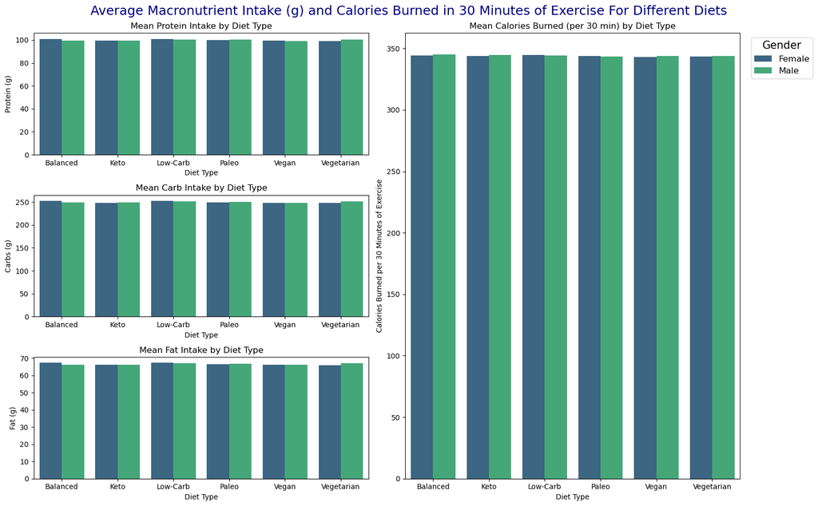

|  | diet_type | Gender | protein_mean | protein_median | carb_mean | carb_median | fat_mean | fat_median | calories_burned_mean | calories_burned_median | total_count |
| --- | --- | --- | --- | --- | --- | --- | --- | --- | --- | --- | --- |
| 0 | Balanced | Female | 101.019981 | 98.070 | 252.479553 | 245.130 | 67.345447 | 65.330 | 344.267084 | 348.830 | 1612 |
| 1 | Balanced | Male | 99.416813 | 96.180 | 248.505364 | 239.820 | 66.271455 | 64.110 | 345.251486 | 349.385 | 1622 |
| 2 | Keto | Female | 99.318822 | 96.250 | 248.298408 | 240.690 | 66.214548 | 64.310 | 344.028484 | 348.160 | 1715 |
| 3 | Keto | Male | 99.414525 | 97.100 | 248.532063 | 243.040 | 66.287738 | 64.640 | 344.492958 | 347.870 | 1609 |
| 4 | Low-Carb | Female | 100.972185 | 97.670 | 252.387213 | 244.190 | 67.312029 | 65.220 | 344.841740 | 349.100 | 1661 |
| 5 | Low-Carb | Male | 100.567625 | 98.275 | 251.410815 | 245.665 | 67.046607 | 65.415 | 344.183906 | 348.235 | 1718 |
| 6 | Paleo | Female | 99.844501 | 96.910 | 249.595756 | 242.200 | 66.549019 | 64.580 | 343.935960 | 348.060 | 1713 |
| 7 | Paleo | Male | 100.262154 | 97.520 | 250.600349 | 243.600 | 66.840402 | 64.985 | 343.471183 | 348.820 | 1690 |
| 8 | Vegan | Female | 99.344563 | 96.850 | 248.371788 | 241.780 | 66.230547 | 64.540 | 343.159513 | 348.080 | 1683 |
| 9 | Vegan | Male | 99.198695 | 96.595 | 247.991366 | 241.450 | 66.136793 | 64.465 | 343.663085 | 349.385 | 1640 |
| 10 | Vegetarian | Female | 99.025359 | 96.675 | 247.520219 | 241.675 | 66.018066 | 64.500 | 343.465067 | 348.805 | 1644 |
| 11 | Vegetarian | Male | 100.608789 | 97.180 | 251.582617 | 243.180 | 67.076911 | 64.840 | 343.860396 | 348.960 | 1693 |

Looking at the barplots, it appears that different types of diets don’t have much variation in macronutrient intake. Similarly, different types of diets burn a similar amount calories in 30 minutes of exercise, on average, across males and females. Each diet type and gender combination have a similar number of observations, so certain groups are not vulnerable to drastic change that can account for the lack of clear patterns portrayed by this visualization.

This graph also implies that both males and females consume approximately the same amount of macronutrients in grams across all diet types, which also implies that this dataset contains individuals where everyone consumes approximately the same amount of calories. For example, the mean intake of protein across all diet types are 99-100g for both males and females, and similarly the mean intake of carbs across all diet types are 247-252g for both males and females. This observation may seem strange, as it conflicts with the idea that certain diet types are designed specifically to lower/raise the intake of a certain macronutrient. For example, one of the diets are labeled as “Low-Carb”, but the visualization does not reflect the idea that this diet consumes less carbs on average compared to other diets. There is also little to no variation for intake across males and females, which may also be contradictory to one’s intuition that would expect females to consume slightly lower amounts of macronutrients (meaning less total calories) on average due to biological factors such as less height or lower body weight. Additionally, the table suggests that males and females burn a similar number of calories per 30 minutes of exercise. Again, this observation may seem unusual because of biological differences that may encourage females to burn slightly less calories than men during exercise, such as lower muscle mass and higher levels of estrogen (promotes body fat storage over muscle building), for example. Generally, the findings of this analysis point to the idea that macronutrient intake remains relatively the same across different diet types, and that each diet type will burn approximately the same amount of calories per 30 minutes of exercise.

#### Final Thoughts

After exploring the relationship of macronutrient intake and workout session duration for both males and females, according to the dataset, it appears that there is no correlation between the amount consumed and workout duration. Generally, it appears that diets with a low, moderate, and high intake of a certain macronutrient will end up sustaining a workout for approximately the same amount of time, with minuscule differences of about 3 minutes.

Similarly, upon analyzing the macronutrient composition across different diets and how it may affect an individual’s amount of calories burned per 30 minutes of exercise, the visualizations and dataset come to a similar conclusion that there is little to no pattern between diet and calories burned. It seems that different diet types consume approximately the same amount of macronutrients for both males and females, and that calories burned is also not affected by the diet type an individual is following.

In short, there is no concrete conclusion that can be drawn from these visualizations utilizing the dataset I chose to confidently anvswer my problem statements. There is no distinguishable difference or pattern between macronutrient intake and workout performance metrics across males and females. It is possible that there are limitations in this dataset, where it was artificially generated and synthetic to result in little to no variability. As a result, I was inhibited in my analysis on seeing more clear relationships between these variables, even for groups that are expected to have a clear relationship in an intuitive sense. Therefore, it is unlikely that this dataset is something derived from the real-world, which can explain why no strong relationships can be extracted between these variables that make sense realistically.

### b) Analysis 2

#### Analyzing Relationship Between Workout Experience Level and BMI

The Experience_Level variable is given as floats, ranging from 1 to 3.05. In the Kaggle dataset description, it states that 1 corresponds to beginner, 2 corresponds to intermediate, while 3 corresponds to advanced. Since the values are given as floats, I have decided to bin the Experience_Level variable and have the beginner group range from 1 to 1.99, the intermediate group range from 2 to 2.99, and advanced group include values 3 and higher. This method will allow for greater readability and understanding by grouping observations under a category based on the description of the dataset, instead of leaving them as floats which may be difficult for further analysis. This method can also avoid subjectivity in what defines a beginner, intermediate, or advanced person in fitness, and these thresholds are also explicitly stated in the dataset description.

|  | Workout Experience Level | Experience Level Range | Number of Observations |
| --- | --- | --- | --- |
| 0 | Beginner | 1.0 – 2.0 | 11912 |
| 1 | Intermediate | 2.0 – 3.0 | 5215 |
| 2 | Advanced | 3.0 – 3.05 | 1420 |

Looking at the number of observations across the experience levels, the “Beginner” workout experience level appears to have significantly more observations than the “Intermediate” and “Advanced” workout experience levels. To further visualize the relationship between experience level and health metrics, it is important to keep the number of observations under each bin into consideration in cases where there are greater variability and differences in statistical information.

Now, I am going to focus on investigating the relationship between experience level with BMI using the data in which BMI < 16 was filtered out.

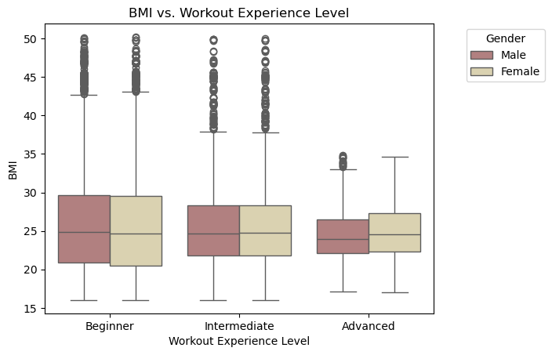

|  | Experience Level | Gender | count | mean | median | q1 | q3 | IQR | Outliers |
| --- | --- | --- | --- | --- | --- | --- | --- | --- | --- |
| 0 | Beginner | Female | 5938 | 25.736750 | 24.62 | 20.5100 | 29.5475 | 9.0375 | 143 |
| 1 | Beginner | Male | 5974 | 25.965405 | 24.82 | 20.8925 | 29.6250 | 8.7325 | 169 |
| 2 | Intermediate | Female | 2653 | 25.709778 | 24.79 | 21.8200 | 28.3300 | 6.5100 | 101 |
| 3 | Intermediate | Male | 2562 | 25.691819 | 24.68 | 21.8100 | 28.3175 | 6.5075 | 102 |
| 4 | Advanced | Female | 692 | 24.991373 | 24.54 | 22.3550 | 27.3500 | 4.9950 | 0 |
| 5 | Advanced | Male | 728 | 24.582088 | 23.98 | 22.1300 | 26.5100 | 4.3800 | 15 |

Looking at the boxplot, it appears that the average BMI stays consistent throughout each experience level across both males and females. For example, the average BMI for a male and female stays consistent at about 25 regardless of workout experience level. Similarly, the median bmi for both males and females across all levels of workout experience stays approximately around 24. This insight may be unexpected because BMI, defined as a quick screening tool that uses weight and height to estimate an individual’s body fat, may be expected to have a more distinguishable relationship with workout experience (e.g. beginners may have higher BMIs due to just beginning their fitness journeys). However, this visualization suggests that the average BMI stays consistent across all levels of workout experience. Another thing to consider is the differing sizes of the interquartile range for each workout experience level and gender combination. Considering that the interquartile range represents the middle 50% of the data, it appears that the beginner experience level has greater variability in terms of BMI compared to intermediate or advanced experience levels. This observation can also be attributed to the fact that the beginner experience level group has signfiicantly more observations, which may contribute to greater variation of BMI in the interquartile range.

There are also more outliers visible above the upper fence, which can be explained by the fact that I chose to filter out possibly fatal BMI values that are not achievable. But, these extremely higher values are still achievable, but should not be ignored in attempts to mimic real-world scenarios with naturally high variation among individuals.

With this being said, there is no clear correlation or relationship between the level of workout experience and an individual’s BMI. The visualization indicates that despite workout experience level, BMI will not be affected. However, today, it is common to perceive BMI as “inaccurate” or “outdated”, as it does not distinguish the difference between muscle and fat. As it mainly focuses on an individual’s weight, it is possible that BMI overestimates health risks for more muscular individuals, and underestimates health risks for individuals with low muscle mass. Therefore, another approach I would like to take is to examine fat percentage directly with workout experience level to lessen the impacts of BMI’s limitations.

#### Analyzing Relationship Between Workout Experience Level and Body Fat Percentage

To examine the relationship between workout experience level and body fat percentage, I am following the same idea used above when defining the thresholds for a beginner, intermediate, and advanced individual in fitness as well as binning the Experience_Level variable. The thresholds will remain the same, where [1,2) correspond to “Beginner”, [2,3) correspond to “Intermediate”, and 3 and above correspond to “Advanced”. Instead of visualizing experience level with BMI though, I will now be focusing on visualizing experience level with fat percentage using the same data with BMI < 16 filtered out. Even though I am not using BMI in this plot, including the filtered out observations not included previously may introduce new trends and patterns specific to these filtered observations, which makes comparison between these two plots less practical.

|  | Workout Experience Level | Experience Level Range | Number of Observations |
| --- | --- | --- | --- |
| 0 | Beginner | 1.0 – 2.0 | 11912 |
| 1 | Intermediate | 2.0 – 3.0 | 5215 |
| 2 | Advanced | 3.0 – 3.05 | 1420 |

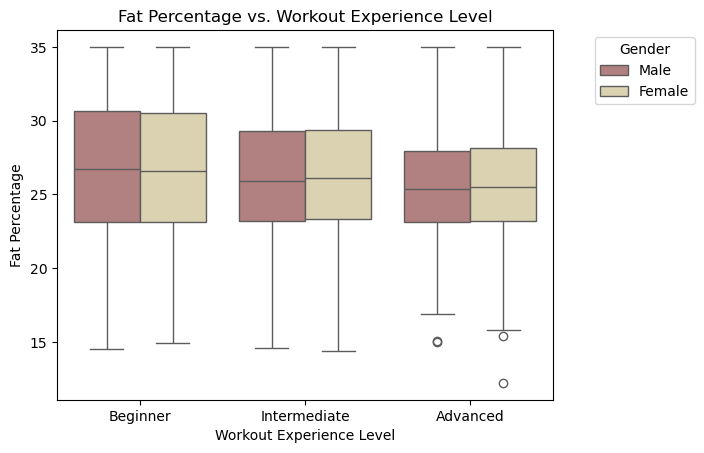

|  | Experience Level | Gender | count | mean | median | q1 | q3 | IQR | Outliers |
| --- | --- | --- | --- | --- | --- | --- | --- | --- | --- |
| 0 | Beginner | Female | 5938 | 26.870315 | 26.596755 | 23.104323 | 30.517200 | 7.412877 | 0 |
| 1 | Beginner | Male | 5974 | 27.016155 | 26.729580 | 23.131270 | 30.635247 | 7.503977 | 0 |
| 2 | Intermediate | Female | 2653 | 26.503088 | 26.129580 | 23.357447 | 29.377557 | 6.020110 | 0 |
| 3 | Intermediate | Male | 2562 | 26.386367 | 25.908383 | 23.223487 | 29.308319 | 6.084831 | 0 |
| 4 | Advanced | Female | 692 | 25.722618 | 25.535387 | 23.181872 | 28.132323 | 4.950451 | 2 |
| 5 | Advanced | Male | 728 | 25.673748 | 25.402983 | 23.150111 | 27.943975 | 4.793864 | 2 |

Looking at the boxplot, a similar result emerges. It appears that fat percentage stays consistent throughout each experience level across both males and females. For both males and females, there is no significant difference in average fat percentage across experience level, as it is restricted to around 25-27% body fat. Again, these results may seem unusual, as intuitively, it is expected for those who are more experienced in fitness to have a lower body fat percentage. Even with the limitations of examining BMI, isolating body fat percentage itself did not seem to reveal any new patterns in relation to experience level. Another important note is that the average body fat percentage between males and females are very close across all levels in the data. For example, both males and females average about 26% body fat percentage with intermediate experience. Similarly, it can come across as unusual where females are expected to have a higher body fat percentage than males due to biological differences (e.g. higher estrogen levels, which promotes greater fat storage for reproduction purposes). However, across all experience levels, females and males have almost the same average body fat percentages.

Additionally, similar to the pattern noticed when visualizing BMI and experience level, the interquartile range (middle 50% of data) for the beginner group, again indicating greater variability (i.e. larger interquartile range) in fat percentage in comparison to the interquartile ranges of the intermediate and advanced groups. Again, a possible explanation for this is the increased number of observations, which can provide an opportunity for more variance in this group.

As a whole, it appears that there is no clear relationship between the level of workout experience and an individual’s fat percentage. On average, it appears that fat percentage remains consistent despite level of workout experience, lacking any strong patterns or trends between these two variables. The dataset does not state how Experience_Level was collected. Therefore it is possible that Experience_Levels are self-reported. This consideration can provide possible explanations as to why a clear pattern is not distinguishable when examining experience level. Experience level may be subjective, where individuals may have reported their experience levels on different criteria. Consequently, rather than investigating the relationship of health metrics and experience level, it may be valuable to examine the relationship of health metrics with workout frequency instead.

#### The Relationship Between Resting Heart Rate and Workout Frequency

The Workout_Frequency (days/week) variable is given as a float rather than an integer. It is possible that the values are reported as an average of workout frequency over an extended period of time. To account for this, I binned the Workout_Frequency (days/week) variable into low, moderate, and high frequency groups. The thresholds for these labels are subjective, so I tried to evenly space the groups out so each category covers 2-3 days out of the week. I chose to categorize [0,2) days a week as low frequency, [2, 4) days a week as moderate frequency, and 4 or more days a week as high frequency. Similar to binning experience level, I chose to bin workout frequency in this case to allow for greater readability and understanding by categorizing the values instead of leaving them as floats. I also chose to create low, moderate, and high frequency bins instead of 7 total bins representing working out 1-7 days a week due to the fact that the values are floats. For an example, if a value is reported as 2.5, it would be difficult to decide whether to label this individual as working out 2 days a week or 3 days a week. Therefore, I created low, moderate, and high frequency bins to avoid ambiguity.

|  | Workout Frequency (days/week) | Workout Frequency Range | Number of Observations |
| --- | --- | --- | --- |
| 0 | Low Frequency | 0 – 2 | 2309 |
| 1 | Moderate Frequency | 2 – 4 | 11872 |
| 2 | High Frequency | 4 – 7.00 | 4366 |

Looking at the number of observations for each workout frequency (days/week) group, the moderate frequency group has significantly more observations than the low or high frequency group. This observation is worth considering when analyzing the visualizations with frequency and resting heart rate, as it is possible to have great variation or vastly different statistical information. For groups with lower numbers of observations, their averages are more vulnerable to drastic change from extreme values or outliers. While data cleaning, I observed that neither the Workout Frequency (days/week) variable or Resting_BPM variable have outliers, so this should not be a large concern.

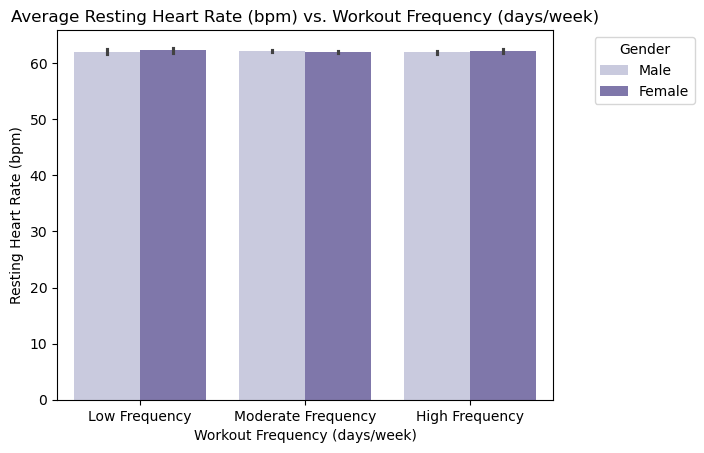

|  | Workout Frequency | Gender | mean | median | count | CI_lower | CI_upper |
| --- | --- | --- | --- | --- | --- | --- | --- |
| 0 | Low Frequency | Female | 62.295455 | 62.290 | 1186 | 61.867717 | 62.723193 |
| 1 | Low Frequency | Male | 62.028424 | 62.020 | 1123 | 61.587475 | 62.469373 |
| 2 | Moderate Frequency | Female | 62.037194 | 62.090 | 5906 | 61.854332 | 62.220057 |
| 3 | Moderate Frequency | Male | 62.222358 | 62.825 | 5966 | 62.041571 | 62.403146 |
| 4 | High Frequency | Female | 62.169051 | 62.040 | 2191 | 61.858347 | 62.479755 |
| 5 | High Frequency | Male | 61.902543 | 61.970 | 2175 | 61.588460 | 62.216625 |

Looking at the bar plot, there does not appear to be a substantial relationship between resting heart rate and workout frequency. For both males and females, the mean resting heart rate stays consistent at approximately 62 beats per minute across all workout frequency groups. Additionally, the errorbars appear small and condensed, which suggest that the data is consistent, many observations clustering around the mean value with small variation. Due to the data’s small variation, the 95% confidence interval bounds are very close to each other. For each workout frequency group, the lower bound for the confidence interval is between 61 and 62, while the upper bound for the confidence interval is between 62 and 63. For example, I am 95% confident that the true average resting heart rate for low workout frequency group among females lies between 61.87 and 62.72 bpm. This generally applies for all the workout frequency groups in a similar fashion. Additionally, the small confidence interval indicates that the data has very little uncertainty in estimating the mean resting heart rate, which can possibly be attributed to low variation and large sample size.

These results may come across as shocking. Intuitively, people may expect athletes (who exercise very frequently) to have a lower resting heart rate due to stronger cardiovascular health, where the heart is more efficient in pumping blood throughout the body. However, the findings from my data suggest that all individuals average a resting heart rate around 61 to 62 bpm despite workout frequency. It is also important to consider other variables that may affect these unexpected results that haven’t been accounted for here. It is true that there is no distinct pattern or clear relationship between resting heart rate and workout frequency in this dataset, but things like age or sleep health could have also affected the average resting heart rate of individuals in this dataset, which could have affected this analysis.

#### Final Thoughts

Upon exploring the relationship of different health metrics (BMI, fat percentage, and resting heart rate) with workout frequencies/experience level, the results are inconclusive, where there are not any real differences between workout frequency/experience level groups and health metrics for both males and females according to this dataset. Generally, it appears that individuals with a beginner, intermediate, and advanced workout experience level end up with very similar health metrics like BMI and fat percentage. Similarly, the data suggests that individuals have very similar resting heart rates among all levels of workout frequency. In all of these results, there is no distinct pattern or correlation that can be drawn when examining the relationship between these variables.

In short, there is no concrete conclusion that can be drawn on how health metrics vary across groups of differing workout frequency and experience level. There is no distinguishable difference between health metrics and fitness experience or frequency, at least for the health metrics that I chose to analyze. As stated in the analysis for problem statement 1, this observation can be attributed to possible limitations in the dataset, whether it was artificially generated to have little variability rather than a dataset derived from the real-world and real individuals.

### c) Analysis 3

#### Proportion of Observations of Each Diet Type per Workout Type

To explore any patterns between diet type and workout type, I first visualized the proportions as a bar plot to see if certain diet types preferred to do one type of workout over another.

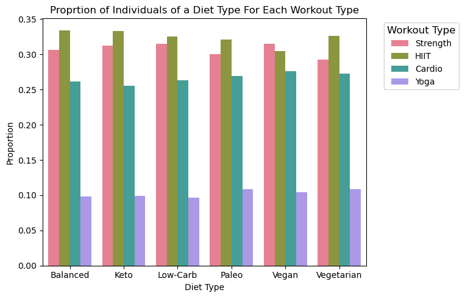

|  | diet_type | Workout_Type | Observation Count | Proportion |
| --- | --- | --- | --- | --- |
| 0 | Balanced | Cardio | 565 | 0.261211 |
| 1 | Balanced | HIIT | 723 | 0.334258 |
| 2 | Balanced | Strength | 663 | 0.306519 |
| 3 | Balanced | Yoga | 212 | 0.098012 |
| 4 | Keto | Cardio | 577 | 0.255762 |
| 5 | Keto | HIIT | 752 | 0.333333 |
| 6 | Keto | Strength | 704 | 0.312057 |
| 7 | Keto | Yoga | 223 | 0.098848 |
| 8 | Low-Carb | Cardio | 593 | 0.262971 |
| 9 | Low-Carb | HIIT | 734 | 0.325499 |
| 10 | Low-Carb | Strength | 710 | 0.314856 |
| 11 | Low-Carb | Yoga | 218 | 0.096674 |
| 12 | Paleo | Cardio | 611 | 0.269519 |
| 13 | Paleo | HIIT | 728 | 0.321129 |
| 14 | Paleo | Strength | 681 | 0.300397 |
| 15 | Paleo | Yoga | 247 | 0.108955 |
| 16 | Vegan | Cardio | 610 | 0.275769 |
| 17 | Vegan | HIIT | 674 | 0.304702 |
| 18 | Vegan | Strength | 697 | 0.315099 |
| 19 | Vegan | Yoga | 231 | 0.104430 |
| 20 | Vegetarian | Cardio | 618 | 0.272607 |
| 21 | Vegetarian | HIIT | 739 | 0.325981 |
| 22 | Vegetarian | Strength | 664 | 0.292898 |
| 23 | Vegetarian | Yoga | 246 | 0.108513 |

Looking at the bar plot, under each workout type, there is a different proportion of individuals who follow a specific diet that prefer different types of workouts. For example, about 26% of individuals who follow a “Low-Carb” diet prefer cardio as their form of exercise, while about 9.67% of individuals who follow a “Low-Carb” diet prefer yoga as their form of exercise. When looking at each diet type in isolation, there is variation in the proportions of individuals who prefer different types of workouts. However, when looking at the bar plot as a whole, there is not a distinguishable trend across each diet type and workout type group. For example, across all diet types, between 29.2% and 31.4% of individuals prefer strength training as their form of exercise despite what diet they follow. Upon visual inspection, the bar plot also portrays a relatively consistent bar heights across all diet types, with no visible dramatic drops/increases of bars for any of the workout types. For example, when isolating “Strength” in isolation, there is no strong increase or decrease in the proportion of individuals who partake in strength training across different diet types. The same idea applies for the other workout types as well.

Despite the lack of a clear pattern, now that I have a general idea of the proportion of diet type under each workout type group, I aimed to analyze the average caloric burn (i.e BMR) in a day for each diet type and workout type combination to investigate if certain diet type and exercise type combinations correlate to differences in daily caloric burn.

#### Analyzing Total Calories Burned Per Diet Type and Workout Type

Analying total calories burned within each diet type and workout type combination can help us gauge how different types of workouts are related to differences in caloric output for individuals following the same type of diet. To visualize this relationship, I split the observations based on gender to create separate visualizations for males and females. Because men and women may have different basal metabolic rates and caloric burn ranges on average due to biological differences such as greater muscle mass, it is more meaningful to create separate plots rather than combining observations of both genders and possibly averaging away valuable patterns. Considering differences in bodily needs, it is possible for males and females to get different results in terms of what diet-workout combination correlates to the highest caloric burn.

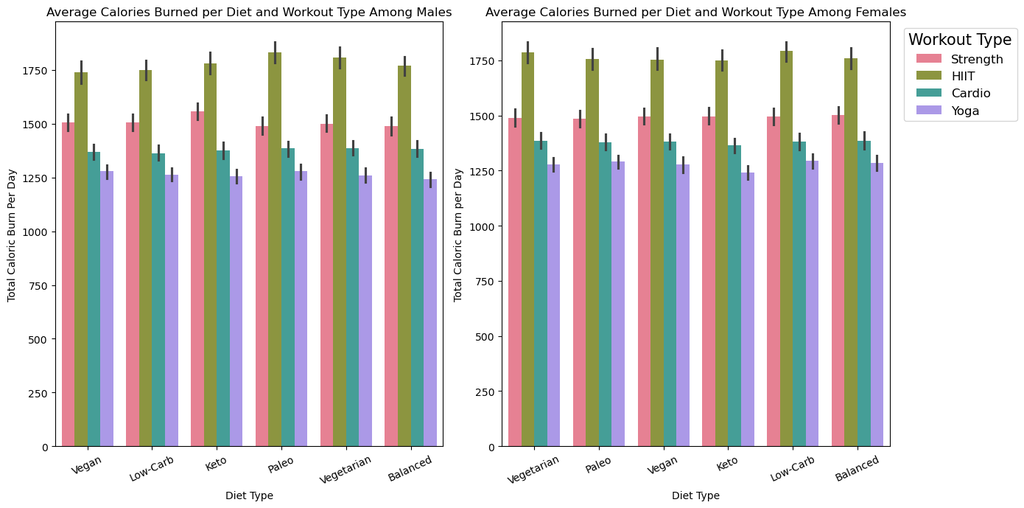

|  | Gender | diet_type | Workout_Type | mean | median | count | CI_lower | CI_upper |
| --- | --- | --- | --- | --- | --- | --- | --- | --- |
| 0 | Female | Balanced | Cardio | 1385.476014 | 1276.000 | 281 | 1347.912856 | 1423.039172 |
| 1 | Female | Balanced | HIIT | 1759.093304 | 1677.800 | 345 | 1714.190863 | 1803.995746 |
| 2 | Female | Balanced | Strength | 1502.956884 | 1394.630 | 353 | 1466.769375 | 1539.144392 |
| 3 | Female | Balanced | Yoga | 1285.045644 | 1306.610 | 101 | 1251.628107 | 1318.463180 |
| 4 | Female | Keto | Cardio | 1364.096346 | 1266.140 | 312 | 1331.172702 | 1397.019991 |
| 5 | Female | Keto | HIIT | 1750.175995 | 1654.690 | 392 | 1705.795088 | 1794.556902 |
| 6 | Female | Keto | Strength | 1496.018630 | 1392.040 | 365 | 1459.354226 | 1532.683034 |
| 7 | Female | Keto | Yoga | 1241.319279 | 1242.110 | 111 | 1210.119937 | 1272.518622 |
| 8 | Female | Low-Carb | Cardio | 1380.676165 | 1287.470 | 279 | 1344.500153 | 1416.852177 |
| 9 | Female | Low-Carb | HIIT | 1792.549263 | 1704.220 | 353 | 1746.839106 | 1838.259420 |
| 10 | Female | Low-Carb | Strength | 1495.821563 | 1392.040 | 371 | 1460.749391 | 1530.893735 |
| 11 | Female | Low-Carb | Yoga | 1295.320816 | 1327.020 | 98 | 1261.407714 | 1329.233918 |
| 12 | Female | Paleo | Cardio | 1378.449345 | 1276.930 | 290 | 1343.056446 | 1413.842244 |
| 13 | Female | Paleo | HIIT | 1755.477326 | 1659.960 | 374 | 1709.094780 | 1801.859872 |
| 14 | Female | Paleo | Strength | 1485.767135 | 1393.200 | 370 | 1449.117576 | 1522.416694 |
| 15 | Female | Paleo | Yoga | 1289.698189 | 1310.400 | 127 | 1261.012400 | 1318.383978 |
| 16 | Female | Vegan | Cardio | 1381.558129 | 1286.935 | 310 | 1347.657408 | 1415.458850 |
| 17 | Female | Vegan | HIIT | 1752.465015 | 1660.430 | 341 | 1703.094284 | 1801.835745 |
| 18 | Female | Vegan | Strength | 1495.731637 | 1395.130 | 342 | 1458.908135 | 1532.555140 |
| 19 | Female | Vegan | Yoga | 1277.290171 | 1287.000 | 117 | 1243.062556 | 1311.517786 |
| 20 | Female | Vegetarian | Cardio | 1385.475292 | 1278.930 | 291 | 1349.774032 | 1421.176552 |
| 21 | Female | Vegetarian | HIIT | 1787.330084 | 1704.550 | 359 | 1739.642651 | 1835.017516 |
| 22 | Female | Vegetarian | Strength | 1488.501826 | 1385.280 | 334 | 1450.935094 | 1526.068559 |
| 23 | Female | Vegetarian | Yoga | 1277.591304 | 1308.380 | 115 | 1244.651605 | 1310.531003 |
| 24 | Male | Balanced | Cardio | 1382.502148 | 1284.480 | 284 | 1346.673798 | 1418.330498 |
| 25 | Male | Balanced | HIIT | 1769.950079 | 1676.400 | 378 | 1724.257374 | 1815.642785 |
| 26 | Male | Balanced | Strength | 1488.701581 | 1386.630 | 310 | 1449.365846 | 1528.037316 |
| 27 | Male | Balanced | Yoga | 1241.132252 | 1241.150 | 111 | 1207.567152 | 1274.697352 |
| 28 | Male | Keto | Cardio | 1374.458868 | 1267.200 | 265 | 1336.710100 | 1412.207636 |
| 29 | Male | Keto | HIIT | 1781.105778 | 1653.720 | 360 | 1730.675855 | 1831.535700 |
| 30 | Male | Keto | Strength | 1558.795634 | 1453.980 | 339 | 1518.986167 | 1598.605102 |
| 31 | Male | Keto | Yoga | 1255.030446 | 1274.810 | 112 | 1222.468959 | 1287.591934 |
| 32 | Male | Low-Carb | Cardio | 1362.939076 | 1283.360 | 314 | 1329.399608 | 1396.478545 |
| 33 | Male | Low-Carb | HIIT | 1750.426955 | 1651.380 | 381 | 1705.075135 | 1795.778776 |
| 34 | Male | Low-Carb | Strength | 1505.405251 | 1395.520 | 339 | 1467.000447 | 1543.810054 |
| 35 | Male | Low-Carb | Yoga | 1264.413833 | 1294.800 | 120 | 1234.039547 | 1294.788120 |
| 36 | Male | Paleo | Cardio | 1385.052741 | 1285.330 | 321 | 1351.973383 | 1418.132100 |
| 37 | Male | Paleo | HIIT | 1832.459887 | 1730.470 | 354 | 1785.109687 | 1879.810087 |
| 38 | Male | Paleo | Strength | 1489.887685 | 1389.780 | 311 | 1450.752240 | 1529.023129 |
| 39 | Male | Paleo | Yoga | 1279.453667 | 1312.415 | 120 | 1245.110508 | 1313.796825 |
| 40 | Male | Vegan | Cardio | 1368.586800 | 1271.495 | 300 | 1333.972850 | 1403.200750 |
| 41 | Male | Vegan | HIIT | 1739.580030 | 1644.100 | 333 | 1688.673786 | 1790.486274 |
| 42 | Male | Vegan | Strength | 1504.953972 | 1384.740 | 355 | 1466.115904 | 1543.792040 |
| 43 | Male | Vegan | Yoga | 1278.954737 | 1324.980 | 114 | 1247.226608 | 1310.682866 |
| 44 | Male | Vegetarian | Cardio | 1386.631223 | 1284.260 | 327 | 1353.272431 | 1419.990016 |
| 45 | Male | Vegetarian | HIIT | 1807.326000 | 1688.190 | 380 | 1759.146199 | 1855.505801 |
| 46 | Male | Vegetarian | Strength | 1500.249697 | 1426.250 | 330 | 1461.650768 | 1538.848626 |
| 47 | Male | Vegetarian | Yoga | 1259.478702 | 1295.800 | 131 | 1227.057147 | 1291.900257 |

Similar to what was observed above, there appears to be variation in calories burned within each diet type in isolation. For example, for both males and females, the average caloric burn in a day for an individual following a vegan diet and choosing to partake in yoga burns approximately 1,278 calories a day (which includes at rest). For other individuals following a vegan diet but chooses to partake in strength training, they burn around 1,495 (for females) and 1,500 (for males) calories a day. Though there is variation among diet groups, when exploring patterns across each diet type and exercise type combination, similar trends emerge. In other words, all diets, for males and females alike, are expected to burn the same number of calories in a day for each specific type of exercise. There is natural variation in how bodies of males and females operate on a daily basis, so these results may conflict with real world ideas. Additionally, upon visual inspection, the bar plot also portrays a relatively consistent bar height for each exercise type across all diet types, with no visible dramatic drops/increases of bars (e.g. the height of the “Cardio” bar remains relatively uniform in height across all diet types).

Although there is no concrete conclusions that can be drawn between these variables, it is also important to consider other variables that may have not been accounted for that could have contributed to such low variability. Other factors that may affect daily caloric burn include muscle mass vs. fat mass, genetics, or physiological states like pregnancy.

#### Final Thoughts

After investigating what proportion of individuals under each diet type prefer a certain type of workout and its relation to daily caloric burn, the results are indefinite. There are differences within a singular diet type in how many individuals prefer a certain workout and how many calories are burned in a day, but there is no clear pattern or variation across all workout types. The data suggests that the same proportion of individuals prefer a certain workout and that they will burn the same amount of calories performing a certain workout regardless of what type of diet they are following.

In short, there are no solid deductions that can be drawn on how workout preferences vary across diet types and how different diets differ in caloric burn. The data does suggest that proportion and caloric burn stays uniform for individuals under the same workout type, indicating that there is no strong relationship between these variables. Intuitively, this finding may conflict with pre-existing knowledge of nutrition and fitness. Similar to what was stated in previous analyses, this observation can be attributed to possible limitations in the dataset, where there is extremely low variability (supported by the small confidence intervals for each group), or the dataset was artificially generated rather than derived from real-world data.

## 7) Recommendations to Stakeholders

### a) Recommendations 1

For both everyday people who may feel overwhelmed about encountering conflicting nutritional/fitness information on social media and fitness trainers alike, there is no singular recommendation that can be given from these findings. Based on the dataset that was utilized, there is no clear relationship or trend between macronutrient intake with workout duration or calories burned during exercise, as the findings suggest that no matter what an individual’s macronutrient intake is, session duration and calories burned during exercise will remain uniform. This indicates that there is no difference between groups different macronutrient levels and exercise metrics, which is not realistic.

This observation can be attributed to poor data quality, in which there was little to no variation in the variables to see a clear pattern in these relationships. The data is likely synthetic, where variables have narrower ranges that contrast with the real world’s naturally high variation according to differences in lifestyles and bodies. It creates unrealistic relationships between the variables, where averages remain consistent across all groups alike, including gender, which is not what we would typically expect in a real world application of the same variables. Therefore, the findings of this dataset should not be used for real world applications. To overcome limitations in analysis, it will be more applicable and generalizable if a more realistic dataset with natural variation was utilized, allowing for clearer trends and patterns to emerge. In this dataset, findings are inconclusive due to the its artificial nature with small variability conflicting with real world scenarios. If a dataset derived from real-world sources were used, more distinct trends and relationships may emerge that can pave the way for providing more reliable recommendations.

These findings may not reflect results that are expected in the real world. For example, it is expected that increasing the intake of carbs to help increase workout sessions due to carbs being the body’s primarily and readily available fuel source. Higher protein diets may also correlate with more calories burned during exercise, as it promotes muscle building (which burns more calories than fat). It is also expected for different diet types to consist of different macronutrient compositions based on bodily needs.

Although these findings do not present any definitive results, it is still vital for people who are interested in changing their lifestyle and habits to rely on scientifically accurate resources when researching topics under fitness and exercise so that they are able to follow a plan that works specifically for the own individualized bodily needs and goals. Following social media influencers’ advice without skepticism or further research can be harmful and inefficient improving your lifestyle because everyone’s bodies have different needs to be healthy. For fitness trainers, it is also important for them to rely on scientifically supported resources to recommend clients specific diets or fitness advice, as individuals are all at different spots in their personal fitness and nutrition journeys. Fitness and nutrition is not a one-size-fits-all, and varies from person to person. Do what works for your body, and don’t feel pressured to follow a certain diet/workout routine just because someone else is!

### b) Recommendations 2

For both everyday people who are interested in changing their lifestyle habits and fitness trainers, there are no clear-cut deductions on these findings analyzing the relationship between workout frequency and level with various health metrics to provide an ample recommendation. The data suggests that health metrics will remain relatively uniform despite workout frequency and experience. This indicates that there is no difference between groups who are more/less experienced or workout more/less frequently in terms of health metrics, which is not realistic. Therefore, the findings of this dataset should not be used for real world or serve as a reliable recommendation to people and fitness trainers.

Similar to the observations made in exploring problem statement 1, this remark may be attributed to poor data quality, which had little variation and narrow ranges among the variables I focused on examining. This demonstrates unrealistic relationships between the variables within this dataset that conflicts with ideas you expect in a real world scenario. To overcome limitations in analysis, it will be more applicable and generalizable if a more realistic dataset with natural variation was analyzed. The dataset appears to be synthetic and have very small variation across all variables that I focused on. If a dataset derived from real-world sources were used, more distinct trends and relationships may emerge that can pave the way for providing more accurate recommendations.

Realistically, there are relationships that one would expect to see between some of these variables, even though this dataset specifically yielded indeterminate results. For example, for both males and females, it is expected for individuals with more experience in fitness and exercise to have a lower body fat percentage, as their expertise and consistency in exercising can provide them an accurate idea of what lifestyle changes and actions to take to best take care of their bodies and reach their physical goals. Similarly it is expected for individuals with higher workout frequencies to have lower average resting heart rates due to stronger cardiovascular health, where the heart can efficiently pump more blood.

Although these findings did not provide conclusive results, it is still important that people who are interested in changing their lifestyle stay motivated in reaching their goals. In the real world, it is true that consistent exercise impacts the body in a positive way, even though my results did not necessarily support this fact. If you are interested in changing your habits to be healthier and work towards things like lowering body fat percentage, it is okay to start as a beginner and workout less frequently at the start. Gauge what exercises you like and what foods work for you before commiting to becoming more advanced and exercising more frequently to reach your personal goals. Do not be discouraged by these results. It is still possible to reach your fitness goals and improve your overall health through consistent hard work in prioritizing fitness and nutrition.

### c) Recommendations 3

Similar to remarks made in previous problem statements, there are no definitive conclusions that can be drawn from the results of my analysis which focused on workout preferences across diet types and how it may relate to daily caloric burn. The data indicates that there is no difference between diet type and workout type groups in terms of preference and caloric burn, which is not realistic. Therefore, the findings of this dataset should not be used for real world applications and as a resource for providing lifestyle recommendations.

Like mentioned in my observations in previous problem statements, this lack of difference between groups may be ascribed to poor data quality. There was very small variability in the variables that I was analyzing, which conflicts with realistic, natural variation among the population due to differences in biological factors and lifestyle. Because of the limitations of the dataset, it may have created unrealistic relationships between variables that conflict with real world knowledge. It does seem that yoga burns the least amount of calories and that HIIT training burns the most, but this conclusion can not be made confidently if the data has little to no variation across groups. To overcome limitations in analysis, it will be more applicable and generalizable if a more realistic dataset with natural variation was analyzed and are more supportive of intuitive, pre-existing knowledge. If a dataset derived from real-world sources were used, more distinct trends and relationships may emerge that can pave the way for providing more accurate recommendations.

Realistically, there are relationships one would expect to see between some of these variables, even though my findings specifically captured indefinite outcomes. Depending on the demands of each exercise, this is expected to reflect variation among different diet types due to each diet’s differences in supplementing macronutrients. For example, strength training is expected to have a larger proportion of individuals with high protein diets (e.g. Paleo) along with greater caloric burn due to more muscle mass when compared to other groups.

Although these findings did not provide any conclusive results, it is still important that people tailor their lifestyle choices to their individual goals and habits that are sustainable for them. A certain type of diet may be more beneficial in supplementing the type of workout one individual prefers to partake in versus another, so don’t be pressured to follow the exact same diet as someone else, because their exercise routine may be substantially different than yours. In terms of fitness trainers, it is also important that you recommend clients and give them advice that are related to their lifestyle. One type of diet may be suitable for one client who likes yoga, but this same diet may not be suitable for a different client who likes strength training. So it is important to be cautious and considerate of each person’s needs based on their habits.

## 8) Conclusion

In today’s world, there are a wide variety of diets that people choose to follow, each consisting of different intakes in certain macronutrients (proteins, carbs, and fats), whether it be a personal choice or due to health limitations. Similarly, there are endless choices in routes to take in the realm of fitness: what exercises to do, how experienced you want to be, how frequently you partake in activity, etc., which also depends on each individual’s personal lifestyle habits and goals that they want to reach. Tying nutrition and fitness together, an individual’s lifestyle may affect their overall health, which may be further improved or worsened based on nutritional and fitness choices people make. There is also natural variation in overall health metrics due to underlying biological dispositions, which may also affect nutritional choices and fitness performance.

My analysis suggests that there is no definitive conclusion that can be drawn when examining the relationship between fitness, nutrition, and health. The findings of my investigation indicate that certain lifestyle chocies will not make an impact on an individual’s fitness performance or overall health. In other words, it suggests that no matter what an individual’s goal is, whether it be burning more calories a day or lowering body fat percentage, you can incorporate any diet and built any fitness habit you like to reach your personal goals. There are no diet types of fitness habits that can be made to accelerate progress towards reaching your goals, according to the dataset, as it suggests that there is no real differences between groups of differing nutritional intake or fitness metrics. These findings conflict with realistic fitness and nutrition rationale, where natural variation in human bodies and goals correlate to differences in lifestyle choices and habits. By analyzing these results, people who are interested in changing their lifestyle habits should not be discouraged in reaching their goals and maintain motivation to reach their personal goals. It is evident that more exploration should be done examining the relationships between health, fitness, and nutrition utilizing a dataset with more natural variation of real-world people to be better generalizable to larger populations with different bodily needs and fitness goals.

## References

#### Inspiration

[1] Jabrin, Janis. “Is that nutrition advice on social media legit? Here’s how to tell.” National Geographic, October 2, 2025. https://www.nationalgeographic.com/health/article/nutrition-social-media-science-misinformation

[2] Minsberg, Talya. “The Fitness Trends That Experts Hate”. New York Times, January 3, 2025. https://www.nytimes.com/2025/01/03/well/move/fitness-trends-tiktok-instagram.html

#### Data Cleaning 2

[3] World Health Organization. Moderate and severe thinness, underweight, overweight, obesity. https://apps.who.int/nutrition/landscape/help.aspx?menu=0&helpid=420

#### Data Cleaning 3

[4] Nuckols, Greg. “The (Surprisingly Wide) Range of BMRs in Adults.” MacroFactor, September 18, 2024. https://macrofactorapp.com/range-of-bmrs/

#### Analysis 1

[5] Callahan, Alice, et al. “4.2: Defining Nutrient Requirements- Dietary Reference Intakes.” Medicine Libre Texts. https://med.libretexts.org/Courses/Allan_Hancock_College/Introduction_to_Nutrition_Science_(Bisson_et._al)/04%3A_Dietary_Recommendations/4.02%3A_Defining_Nutrient_Requirements-_Dietary_Reference_Intakes#:~:text=The%20AMDR%20is%20the%20calculated,and%20Protein%2010%2D35%25.